# Cyclistic Case Study

Jessica Mulcrone

2023-09-03

## Task:

The purpose of this analysis is to determine how annual and casual riders use Cyclistic Bikes differently in order to lay the groundwork for a marketing plan to convert more casual riders into annual riders.

## Overview:

Cyclistic Bikes is a bike-share company in Chicago with over 5,800 bicycles and 600 docking stations. In addition to standard bikes, Cyclistic offers assistive options which 8% of their riders utilize. Most customers ride for pleasure but 30% of the user base rent bikes to commute. Cyclistic Bikes has historically focused on appealing to new customers with the flexibility of three pricing plans: single-ride, full-day, and membership, but are now interested in converting existing casual riders into members.

The Cyclistic data analytics team will investigate how annual and casual riders use Cyclistic differently, why casual riders might buy an annual membership, and how social media can influence casual riders to become members. This report addresses the first of these analysis goals: how do annual and casual riders use Cyclist Bikes differently?

## Data Cleaning and Manipulation:

Libraries were imported and working directory was set

```r
library(dplyr)
library(ggplot2)
library(readxl)
library(ggpubr)
library(rstatix)
library(tidyverse)
library(knitr)

rm (list = ls())

setwd ("/Users/mulcron3/Desktop/cyclist_data")
```

Column headers on all sheets were confirmed to match before sheets were imported into R and combined.

```r
data.1 <- read_csv("202207-divvy-tripdata.csv")
data.2 <- read_csv("202208-divvy-tripdata.csv")
data.3 <- read_csv("202209-divvy-publictripdata.csv")
data.4 <- read_csv("202210-divvy-tripdata.csv")
data.5 <- read_csv("202211-divvy-tripdata.csv")
data.6 <- read_csv("202212-divvy-tripdata.csv")
data.7 <- read_csv("202301-divvy-tripdata.csv")
data.8 <- read_csv("202302-divvy-tripdata.csv")
data.9 <- read_csv("202303-divvy-tripdata.csv")
data.10 <- read_csv("202304-divvy-tripdata.csv")
data.11 <- read_csv("202305-divvy-tripdata.csv")
data.12 <- read_csv("202306-divvy-tripdata.csv")

cyclist_compiled <- bind_rows(data.1, data.2)
cyclist_compiled_2 <- bind_rows(data.3, data.4)
cyclist_compiled_3 <- bind_rows(data.5, data.6)
cyclist_compiled_4 <- bind_rows(data.7, data.8)
cyclist_compiled_5 <- bind_rows(data.9, data.10)
cyclist_compiled_6 <- bind_rows(data.11, data.12)
cyclist_compiled_7 <- bind_rows(cyclist_compiled, cyclist_compiled_2)
cyclist_compiled_8 <- bind_rows(cyclist_compiled_3, cyclist_compiled_4)
cyclist_compiled_9 <- bind_rows(cyclist_compiled_5, cyclist_compiled_6)
cyclist_compiled_10 <- bind_rows(cyclist_compiled_7, cyclist_compiled_8)
cyclist_compiled_final <- bind_rows(cyclist_compiled_10, cyclist_compiled_9)
```

Date-time columns were separated while ensuring consistent formatting.

```r
cyclist_compiled_final$start_date <- as.Date(cyclist_compiled_final$started_at)
cyclist_compiled_final$start_time <- format(cyclist_compiled_final$started_at,"%H:%M:%S")
cyclist_compiled_final$end_date <- as.Date(cyclist_compiled_final$ended_at)
cyclist_compiled_final$end_time <- format(cyclist_compiled_final$ended_at,"%H:%M:%S")
```

The data frame was trimmed and rider ID’s were checked for duplicates (none).

```r
cyclist_compiled_final %>%
  mutate(across(where(is.character), str_trim))
```

```r
cyclist_compiled_final[!duplicated(cyclist_compiled_final[c('ride_id')]), ]
```

A column start day-of-week was calculated by extracting day-of-week from start date.

```r
cyclist_compiled_final$start_day_of_week<-weekdays(as.Date(cyclist_compiled_final$start_date,'%Y-%m-%d'))
cyclist_compiled_final$end_day_of_week<-weekdays(as.Date(cyclist_compiled_final$end_date,'%Y-%m-%d'))
```

A column for ride length was calculated by subtracting start time from finish time

```r
cyclist_compiled_final$ride_length<-cyclist_compiled_final$ended_at-cyclist_compiled_final$started_at
```

A column was created for month of start date

```r
cyclist_compiled_final$start_month <- format(as.Date(cyclist_compiled_final$start_date, format="%Y/%m/%d"),"%m")
```

```r
cyclist_compiled_final$ride_length <- as.numeric(cyclist_compiled_final$ride_length)
cyclist_compiled_final$start_month <- as.numeric(cyclist_compiled_final$start_month)
```

Rides with lengths of over one day were investigated and filtered out of the data set as likely either data or user errors*.

```r
rides_over_one_day <-filter(cyclist_compiled_final, ride_length >= 86400)
cyclist_compiled_final <- filter(cyclist_compiled_final, ride_length < 86400)
```

*When large ride lengths were not filtered, monthly max ride lengths hover around a day for members and 10-20 days for casual riders. Excessive max ride length may be a data mistake or riders not returning bikes to stations. Rides over one day made up 0.09% of trips and were much more common among casual riders. They were removed to avoid very long trips artificially inflating average casual ride length.

## Key Questions:

1. Do casual riders and members differ on which days of the week they are most likely to use Cylcistic?
2. Do casual riders and members differ on ride length and is the pattern dependent on day of week?
3. Does daily popularity change month-to-month for casual users or members?
4. Do patterns of ride length change month-to-month for casual users or members?
5. Are casual riders and members most likely to begin a trip from different places?
6. Do casual riders and members prefer different bike types?

## Analysis, Key Results, and Visualizations:

Calculate percentage of each Cyclstic users type overall and by season

```r
nrow(filter(cyclist_compiled_final, member_casual == "member"))
nrow(cyclist_compiled_final)

nrow(filter(cyclist_compiled_final, member_casual == "member" & (start_month == 1 | start_month == 2 | start_month == 3)))
nrow(filter(cyclist_compiled_final, start_month == 1 | start_month == 2 | start_month == 3))

nrow(filter(cyclist_compiled_final, member_casual == "member" & (start_month == 4 | start_month == 5 | start_month == 6)))
nrow(filter(cyclist_compiled_final, start_month == 4 | start_month == 5 | start_month == 6))

nrow(filter(cyclist_compiled_final, member_casual == "member" & (start_month == 7 | start_month == 8 | start_month == 9)))
nrow(filter(cyclist_compiled_final, start_month == 7 | start_month == 8 | start_month == 9))

nrow(filter(cyclist_compiled_final, member_casual == "member" & (start_month == 10 | start_month ==11 | start_month == 12)))
nrow(filter(cyclist_compiled_final, start_month == 10 | start_month == 11 | start_month == 12))
```

Calculate mean ride length by overall, month, and season for all riders, causal riders, and members

```r
ride_length_mean <- mean(cyclist_compiled_final$ride_length)
ride_length_mean_jan <- mean(subset(cyclist_compiled_final, start_month == 1)$ride_length)
ride_length_mean_feb <- mean(subset(cyclist_compiled_final, start_month == 2)$ride_length)
ride_length_mean_march <- mean(subset(cyclist_compiled_final, start_month == 3)$ride_length)
ride_length_mean_april <- mean(subset(cyclist_compiled_final, start_month == 4)$ride_length)
ride_length_mean_may <- mean(subset(cyclist_compiled_final, start_month == 5)$ride_length)
ride_length_mean_june <- mean(subset(cyclist_compiled_final, start_month == 6)$ride_length)
ride_length_mean_july <- mean(subset(cyclist_compiled_final, start_month == 7)$ride_length)
ride_length_mean_aug <- mean(subset(cyclist_compiled_final, start_month == 8)$ride_length)
ride_length_mean_sept <- mean(subset(cyclist_compiled_final, start_month == 9)$ride_length)
ride_length_mean_oct <- mean(subset(cyclist_compiled_final, start_month == 10)$ride_length)
ride_length_mean_nov <- mean(subset(cyclist_compiled_final, start_month == 11)$ride_length)
ride_length_mean_dec <- mean(subset(cyclist_compiled_final, start_month == 12)$ride_length)
ride_length_mean_winter <- mean(subset(cyclist_compiled_final, start_month == 1 | start_month == 2 | start_month == 3)$ride_length)
ride_length_mean_spring <- mean(subset(cyclist_compiled_final, start_month == 4 | start_month == 5 | start_month == 6)$ride_length)
ride_length_mean_summer <- mean(subset(cyclist_compiled_final, start_month == 7 | start_month == 8 | start_month == 9)$ride_length)
ride_length_mean_fall <- mean(subset(cyclist_compiled_final, start_month == 10 | start_month == 11 | start_month == 12)$ride_length)

ride_length_mean_cas <- mean(subset(cyclist_compiled_final, member_casual == 'casual')$ride_length)
ride_length_mean_jan_cas <- mean(subset(cyclist_compiled_final, start_month == 1 & member_casual == 'casual')$ride_length)
ride_length_mean_feb_cas <- mean(subset(cyclist_compiled_final, start_month == 2 & member_casual == 'casual')$ride_length)
ride_length_mean_march_cas <- mean(subset(cyclist_compiled_final, start_month == 3 & member_casual == 'casual')$ride_length)
ride_length_mean_april_cas <- mean(subset(cyclist_compiled_final, start_month == 4 & member_casual == 'casual')$ride_length)
ride_length_mean_may_cas <- mean(subset(cyclist_compiled_final, start_month == 5 & member_casual == 'casual')$ride_length)
ride_length_mean_june_cas <- mean(subset(cyclist_compiled_final, start_month == 6 & member_casual == 'casual')$ride_length)
ride_length_mean_july_cas <- mean(subset(cyclist_compiled_final, start_month == 7& member_casual == 'casual')$ride_length)
ride_length_mean_aug_cas <- mean(subset(cyclist_compiled_final, start_month == 8 & member_casual == 'casual')$ride_length)
ride_length_mean_sept_cas <- mean(subset(cyclist_compiled_final, start_month == 9 & member_casual == 'casual')$ride_length)
ride_length_mean_oct_cas <- mean(subset(cyclist_compiled_final, start_month == 10 & member_casual == 'casual')$ride_length)
ride_length_mean_nov_cas <- mean(subset(cyclist_compiled_final, start_month == 11 & member_casual == 'casual')$ride_length)
ride_length_mean_dec_cas <- mean(subset(cyclist_compiled_final, start_month == 12 & member_casual == 'casual')$ride_length)
ride_length_mean_winter_cas <- mean(subset(cyclist_compiled_final, member_casual == 'casual'& (start_month == 1 | start_month == 2 | start_month == 3))$ride_length)
ride_length_mean_spring_cas <- mean(subset(cyclist_compiled_final, member_casual == 'casual' & (start_month == 4 | start_month == 5 | start_month == 6))$ride_length)
ride_length_mean_summer_cas <- mean(subset(cyclist_compiled_final, member_casual == 'casual' & (start_month == 7 | start_month == 8 | start_month == 9))$ride_length)
ride_length_mean_fall_cas <- mean(subset(cyclist_compiled_final, member_casual == 'casual' & (start_month == 10 | start_month == 11 | start_month == 12))$ride_length)

ride_length_mean_mem <- mean(subset(cyclist_compiled_final, member_casual == 'member')$ride_length)
ride_length_mean_jan_mem <- mean(subset(cyclist_compiled_final, start_month == 1 & member_casual == 'member')$ride_length)
ride_length_mean_feb_mem <- mean(subset(cyclist_compiled_final, start_month == 2 & member_casual == 'member')$ride_length)
ride_length_mean_march_mem <- mean(subset(cyclist_compiled_final, start_month == 3 & member_casual == 'member')$ride_length)
ride_length_mean_april_mem <- mean(subset(cyclist_compiled_final, start_month == 4 & member_casual == 'member')$ride_length)
ride_length_mean_may_mem <- mean(subset(cyclist_compiled_final, start_month == 5 & member_casual == 'member')$ride_length)
ride_length_mean_june_mem <- mean(subset(cyclist_compiled_final, start_month == 6 & member_casual == 'member')$ride_length)
ride_length_mean_july_mem <- mean(subset(cyclist_compiled_final, start_month == 7 & member_casual == 'member')$ride_length)
ride_length_mean_aug_mem <- mean(subset(cyclist_compiled_final, start_month == 8 & member_casual == 'member')$ride_length)
ride_length_mean_sept_mem <- mean(subset(cyclist_compiled_final, start_month == 9 & member_casual == 'member')$ride_length)
ride_length_mean_oct_mem <- mean(subset(cyclist_compiled_final, start_month == 10 & member_casual == 'member')$ride_length)
ride_length_mean_nov_mem <- mean(subset(cyclist_compiled_final, start_month == 11 & member_casual == 'member')$ride_length)
ride_length_mean_dec_mem <- mean(subset(cyclist_compiled_final, start_month == 12 & member_casual == 'member')$ride_length)
ride_length_mean_winter_mem <- mean(subset(cyclist_compiled_final, member_casual == 'member'& (start_month == 1 | start_month == 2 | start_month == 3))$ride_length)
ride_length_mean_spring_mem <- mean(subset(cyclist_compiled_final, member_casual == 'member' & (start_month == 4 | start_month == 5 | start_month == 6))$ride_length)
ride_length_mean_summer_mem <- mean(subset(cyclist_compiled_final, member_casual == 'member' & (start_month == 7 | start_month == 8 | start_month == 9))$ride_length)
ride_length_mean_fall_mem <- mean(subset(cyclist_compiled_final, member_casual == 'member' & (start_month == 10 | start_month == 11 | start_month == 12))$ride_length)
```

Calculate max ride length by overall, month, and season for all riders, causal riders, and members

```r
ride_length_max <- max(cyclist_compiled_final$ride_length)
ride_length_max_jan <- max(subset(cyclist_compiled_final, start_month == 1)$ride_length)
ride_length_max_feb <- max(subset(cyclist_compiled_final, start_month == 2)$ride_length)
ride_length_max_march <- max(subset(cyclist_compiled_final, start_month == 3)$ride_length)
ride_length_max_april <- max(subset(cyclist_compiled_final, start_month == 4)$ride_length)
ride_length_max_may <- max(subset(cyclist_compiled_final, start_month == 5)$ride_length)
ride_length_max_june <- max(subset(cyclist_compiled_final, start_month == 6)$ride_length)
ride_length_max_july <- max(subset(cyclist_compiled_final, start_month == 7)$ride_length)
ride_length_max_aug <- max(subset(cyclist_compiled_final, start_month == 8)$ride_length)
ride_length_max_sept <- max(subset(cyclist_compiled_final, start_month == 9)$ride_length)
ride_length_max_oct <- max(subset(cyclist_compiled_final, start_month == 10)$ride_length)
ride_length_max_nov <- max(subset(cyclist_compiled_final, start_month == 11)$ride_length)
ride_length_max_dec <- max(subset(cyclist_compiled_final, start_month == 12)$ride_length)
ride_length_max_winter <- max(subset(cyclist_compiled_final, start_month == 1 | start_month == 2 | start_month == 3)$ride_length)
ride_length_max_spring <- max(subset(cyclist_compiled_final, start_month == 4 | start_month == 5 | start_month == 6)$ride_length)
ride_length_max_summer <- max(subset(cyclist_compiled_final, start_month == 7 | start_month == 8 | start_month == 9)$ride_length)
ride_length_max_fall <- max(subset(cyclist_compiled_final, start_month == 10 | start_month == 11 | start_month == 12)$ride_length)

ride_length_max_cas <- max(subset(cyclist_compiled_final, member_casual == 'casual')$ride_length)
ride_length_max_jan_cas <- max(subset(cyclist_compiled_final, start_month == 1 & member_casual == 'casual')$ride_length)
ride_length_max_feb_cas <- max(subset(cyclist_compiled_final, start_month == 2 & member_casual == 'casual')$ride_length)
ride_length_max_march_cas <- max(subset(cyclist_compiled_final, start_month == 3 & member_casual == 'casual')$ride_length)
ride_length_max_april_cas <- max(subset(cyclist_compiled_final, start_month == 4 & member_casual == 'casual')$ride_length)
ride_length_max_may_cas <- max(subset(cyclist_compiled_final, start_month == 5 & member_casual == 'casual')$ride_length)
ride_length_max_june_cas <- max(subset(cyclist_compiled_final, start_month == 6 & member_casual == 'casual')$ride_length)
ride_length_max_july_cas <- max(subset(cyclist_compiled_final, start_month == 7 & member_casual == 'casual')$ride_length)
ride_length_max_aug_cas <- max(subset(cyclist_compiled_final, start_month == 8 & member_casual == 'casual')$ride_length)
ride_length_max_sept_cas <- max(subset(cyclist_compiled_final, start_month == 9 & member_casual == 'casual')$ride_length)
ride_length_max_oct_cas <- max(subset(cyclist_compiled_final, start_month == 10 & member_casual == 'casual')$ride_length)
ride_length_max_nov_cas <- max(subset(cyclist_compiled_final, start_month == 11 & member_casual == 'casual')$ride_length)
ride_length_max_dec_cas <- max(subset(cyclist_compiled_final, start_month == 12 & member_casual == 'casual')$ride_length)
ride_length_max_winter_cas <- max(subset(cyclist_compiled_final, member_casual == 'casual'& (start_month == 1 | start_month == 2 | start_month == 3))$ride_length)
ride_length_max_spring_cas <- max(subset(cyclist_compiled_final, member_casual == 'casual' & (start_month == 4 | start_month == 5 | start_month == 6))$ride_length)
ride_length_max_summer_cas <- max(subset(cyclist_compiled_final, member_casual == 'casual' & (start_month == 7 | start_month == 8 | start_month == 9))$ride_length)
ride_length_max_fall_cas <- max(subset(cyclist_compiled_final, member_casual == 'casual' & (start_month == 10 | start_month == 11 | start_month == 12))$ride_length)

ride_length_max_mem <- max(subset(cyclist_compiled_final, member_casual == 'member')$ride_length)
ride_length_max_jan_mem <- max(subset(cyclist_compiled_final, start_month == 1 & member_casual == 'member')$ride_length)
ride_length_max_feb_mem <- max(subset(cyclist_compiled_final, start_month == 2 & member_casual == 'member')$ride_length)
ride_length_max_march_mem <- max(subset(cyclist_compiled_final, start_month == 3 & member_casual == 'member')$ride_length)
ride_length_max_april_mem <- max(subset(cyclist_compiled_final, start_month == 4 & member_casual == 'member')$ride_length)
ride_length_max_may_mem <- max(subset(cyclist_compiled_final, start_month == 5 & member_casual == 'member')$ride_length)
ride_length_max_june_mem <- max(subset(cyclist_compiled_final, start_month == 6 & member_casual == 'member')$ride_length)
ride_length_max_july_mem <- max(subset(cyclist_compiled_final, start_month == 7 & member_casual == 'member')$ride_length)
ride_length_max_aug_mem <- max(subset(cyclist_compiled_final, start_month == 8 & member_casual == 'member')$ride_length)
ride_length_max_sept_mem <- max(subset(cyclist_compiled_final, start_month == 9 & member_casual == 'member')$ride_length)
ride_length_max_oct_mem <- max(subset(cyclist_compiled_final, start_month == 10 & member_casual == 'member')$ride_length)
ride_length_max_nov_mem <- max(subset(cyclist_compiled_final, start_month == 11 & member_casual == 'member')$ride_length)
ride_length_max_dec_mem <- max(subset(cyclist_compiled_final, start_month == 12 & member_casual == 'member')$ride_length)
ride_length_max_winter_mem <- max(subset(cyclist_compiled_final, member_casual == 'member'& (start_month == 1 | start_month == 2 | start_month == 3))$ride_length)
ride_length_max_spring_mem <- max(subset(cyclist_compiled_final, member_casual == 'member' & (start_month == 4 | start_month == 5 | start_month == 6))$ride_length)
ride_length_max_summer_mem <- max(subset(cyclist_compiled_final, member_casual == 'member' & (start_month == 7 | start_month == 8 | start_month == 9))$ride_length)
ride_length_max_fall_mem <- max(subset(cyclist_compiled_final, member_casual == 'member' & (start_month == 10 | start_month == 11 | start_month == 12))$ride_length)
```

Calculate mode day of the week by overall, month, and season for all riders, causal riders, and members

```r
find_mode <- function(x) {
  u <- unique(x)
  tab <- tabulate(match(x, u))
  u[tab == max(tab)]
}

day_of_week_mode <- find_mode(cyclist_compiled_final$start_day_of_week)
day_of_week_mode_jan <- find_mode(subset(cyclist_compiled_final, start_month == 1)$start_day_of_week)
day_of_week_mode_feb <- find_mode(subset(cyclist_compiled_final, start_month == 2)$start_day_of_week)
day_of_week_mode_march <- find_mode(subset(cyclist_compiled_final, start_month == 3)$start_day_of_week)
day_of_week_mode_april <- find_mode(subset(cyclist_compiled_final, start_month == 4)$start_day_of_week)
day_of_week_mode_may <- find_mode(subset(cyclist_compiled_final, start_month == 5)$start_day_of_week)
day_of_week_mode_june <- find_mode(subset(cyclist_compiled_final, start_month == 6)$start_day_of_week)
day_of_week_mode_july <- find_mode(subset(cyclist_compiled_final, start_month == 7)$start_day_of_week)
day_of_week_mode_aug <- find_mode(subset(cyclist_compiled_final, start_month == 8)$start_day_of_week)
day_of_week_mode_sept <- find_mode(subset(cyclist_compiled_final, start_month == 9)$start_day_of_week)
day_of_week_mode_oct <- find_mode(subset(cyclist_compiled_final, start_month == 10)$start_day_of_week)
day_of_week_mode_nov <- find_mode(subset(cyclist_compiled_final, start_month == 11)$start_day_of_week)
day_of_week_mode_dec <- find_mode(subset(cyclist_compiled_final, start_month == 12)$start_day_of_week)
day_of_week_mode_winter <- find_mode(subset(cyclist_compiled_final, start_month == 1 | start_month == 2 | start_month == 3)$start_day_of_week)
day_of_week_mode_spring <- find_mode(subset(cyclist_compiled_final, start_month == 4 | start_month == 5 | start_month == 6)$start_day_of_week)
day_of_week_mode_summer <- find_mode(subset(cyclist_compiled_final, start_month == 7 | start_month == 8 | start_month == 9)$start_day_of_week)
day_of_week_mode_fall <- find_mode(subset(cyclist_compiled_final, start_month == 10 | start_month == 11 | start_month == 12)$start_day_of_week)

day_of_week_mode_cas <- find_mode(subset(cyclist_compiled_final, member_casual == 'casual')$start_day_of_week)
day_of_week_mode_jan_cas <- find_mode(subset(cyclist_compiled_final, start_month == 1 & member_casual == 'casual')$start_day_of_week)
day_of_week_mode_feb_cas <- find_mode(subset(cyclist_compiled_final, start_month == 2 & member_casual == 'casual')$start_day_of_week)
day_of_week_mode_march_cas <- find_mode(subset(cyclist_compiled_final, start_month == 3 & member_casual == 'casual')$start_day_of_week)
day_of_week_mode_april_cas <- find_mode(subset(cyclist_compiled_final, start_month == 4 & member_casual == 'casual')$start_day_of_week)
day_of_week_mode_may_cas <- find_mode(subset(cyclist_compiled_final, start_month == 5 & member_casual == 'casual')$start_day_of_week)
day_of_week_mode_june_cas <- find_mode(subset(cyclist_compiled_final, start_month == 6 & member_casual == 'casual')$start_day_of_week)
day_of_week_mode_july_cas <- find_mode(subset(cyclist_compiled_final, start_month == 7 & member_casual == 'casual')$start_day_of_week)
day_of_week_mode_aug_cas <- find_mode(subset(cyclist_compiled_final, start_month == 8 & member_casual == 'casual')$start_day_of_week)
day_of_week_mode_sept_cas <- find_mode(subset(cyclist_compiled_final, start_month == 9 & member_casual == 'casual')$start_day_of_week)
day_of_week_mode_oct_cas <- find_mode(subset(cyclist_compiled_final, start_month == 10 & member_casual == 'casual')$start_day_of_week)
day_of_week_mode_nov_cas <- find_mode(subset(cyclist_compiled_final, start_month == 11 & member_casual == 'casual')$start_day_of_week)
day_of_week_mode_dec_cas <- find_mode(subset(cyclist_compiled_final, start_month == 12 & member_casual == 'casual')$start_day_of_week)
day_of_week_mode_winter_cas <- find_mode(subset(cyclist_compiled_final, member_casual == 'casual'& (start_month == 1 | start_month == 2 | start_month == 3))$start_day_of_week)
day_of_week_mode_spring_cas <- find_mode(subset(cyclist_compiled_final, member_casual == 'casual' & (start_month == 4 | start_month == 5 | start_month == 6))$start_day_of_week)
day_of_week_mode_summer_cas <- find_mode(subset(cyclist_compiled_final, member_casual == 'casual' & (start_month == 7 | start_month == 8 | start_month == 9))$start_day_of_week)
day_of_week_mode_fall_cas <- find_mode(subset(cyclist_compiled_final, member_casual == 'casual' & (start_month == 10 | start_month == 11 | start_month == 12))$start_day_of_week)

day_of_week_mode_mem <- find_mode(subset(cyclist_compiled_final, member_casual == 'member')$start_day_of_week)
day_of_week_mode_jan_mem <- find_mode(subset(cyclist_compiled_final, start_month == 1 & member_casual == 'member')$start_day_of_week)
day_of_week_mode_feb_mem <- find_mode(subset(cyclist_compiled_final, start_month == 2 & member_casual == 'member')$start_day_of_week)
day_of_week_mode_march_mem <- find_mode(subset(cyclist_compiled_final, start_month == 3 & member_casual == 'member')$start_day_of_week)
day_of_week_mode_april_mem <- find_mode(subset(cyclist_compiled_final, start_month == 4 & member_casual == 'member')$start_day_of_week)
day_of_week_mode_may_mem <- find_mode(subset(cyclist_compiled_final, start_month == 5 & member_casual == 'member')$start_day_of_week)
day_of_week_mode_june_mem <- find_mode(subset(cyclist_compiled_final, start_month == 6 & member_casual == 'member')$start_day_of_week)
day_of_week_mode_july_mem <- find_mode(subset(cyclist_compiled_final, start_month == 7 & member_casual == 'member')$start_day_of_week)
day_of_week_mode_aug_mem <- find_mode(subset(cyclist_compiled_final, start_month == 8 & member_casual == 'member')$start_day_of_week)
day_of_week_mode_sept_mem <- find_mode(subset(cyclist_compiled_final, start_month == 9 & member_casual == 'member')$start_day_of_week)
day_of_week_mode_oct_mem <- find_mode(subset(cyclist_compiled_final, start_month == 10 & member_casual == 'member')$start_day_of_week)
day_of_week_mode_nov_mem <- find_mode(subset(cyclist_compiled_final, start_month == 11 & member_casual == 'member')$start_day_of_week)
day_of_week_mode_dec_mem <- find_mode(subset(cyclist_compiled_final, start_month == 12 & member_casual == 'member')$start_day_of_week)
day_of_week_mode_winter_mem <- find_mode(subset(cyclist_compiled_final, member_casual == 'member'& (start_month == 1 | start_month == 2 | start_month == 3))$start_day_of_week)
day_of_week_mode_spring_mem <- find_mode(subset(cyclist_compiled_final, member_casual == 'member' & (start_month == 4 | start_month == 5 | start_month == 6))$start_day_of_week)
day_of_week_mode_summer_mem <- find_mode(subset(cyclist_compiled_final, member_casual == 'member' & (start_month == 7 | start_month == 8 | start_month == 9))$start_day_of_week)
day_of_week_mode_fall_mem <- find_mode(subset(cyclist_compiled_final, member_casual == 'member' & (start_month == 10 | start_month == 11 | start_month == 12))$start_day_of_week)
```

### Table 1. Summary Table

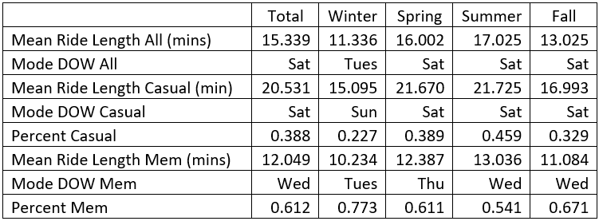

Most rides were taken by members at 61 percent. Members took more rides than casual users every season, though the difference was highest in the winter and lowest in the summer. The mean ride length for members was consistently shorter than causal users. Weekdays were the most popular for members and weekends were most popular for casual users, consistent across seasons.

### Figure 1. Mean Ride Length by Day of Week

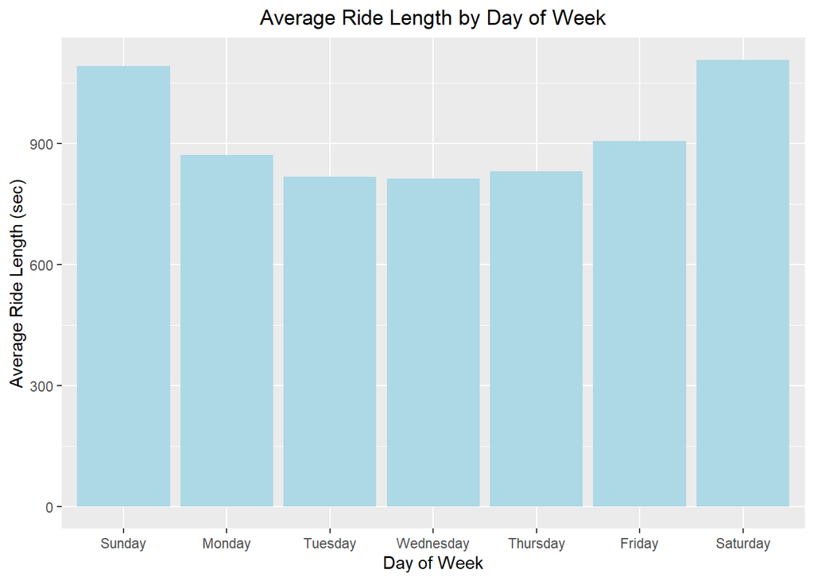

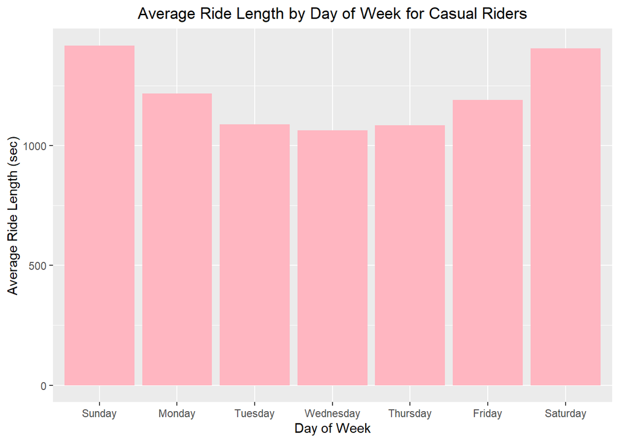

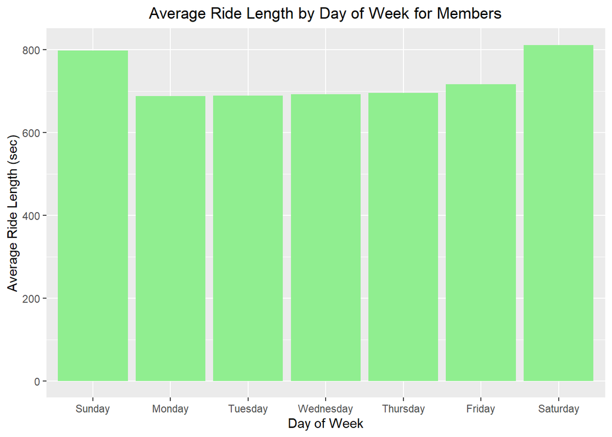

*Do casual riders and members differ on ride length and is the pattern dependent on day of week?*

**Ride length was longest on weekends for all Cyclistic users, though the difference was smaller for members than causal riders. Members had shorter average ride lengths in general. This pattern may be due to member’s commutes being shorter than casual user’s pleasure rides.**

### Figure 2. Mean Ride Length by Day of Week Monthly

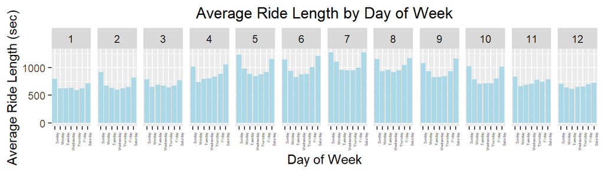

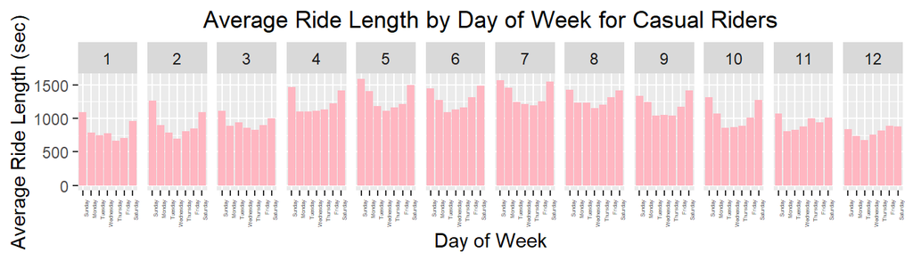

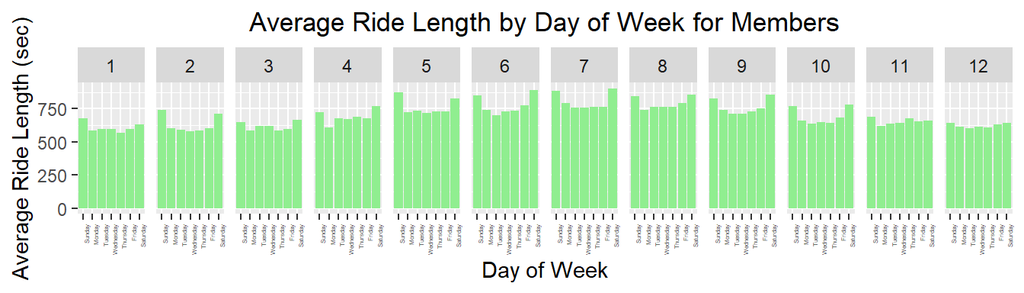

*Do patterns of ride length change month-to-month for casual users or members?*

Ride length is nearly always longest on the weekends for both casual users and members across the year, with casual users consistently showing larger differences between weekends and weekdays. Members have the largest difference between weekends and weekdays in warmer months, while casual users have the largest difference in colder months. **Members might be riding more for pleasure on the weekends in warmer months and casual rider weekday ride length might be greater in summer months due to tourists vacationing on weekdays in addition to weekends.**

### Figure 3. Rides per Day of Week

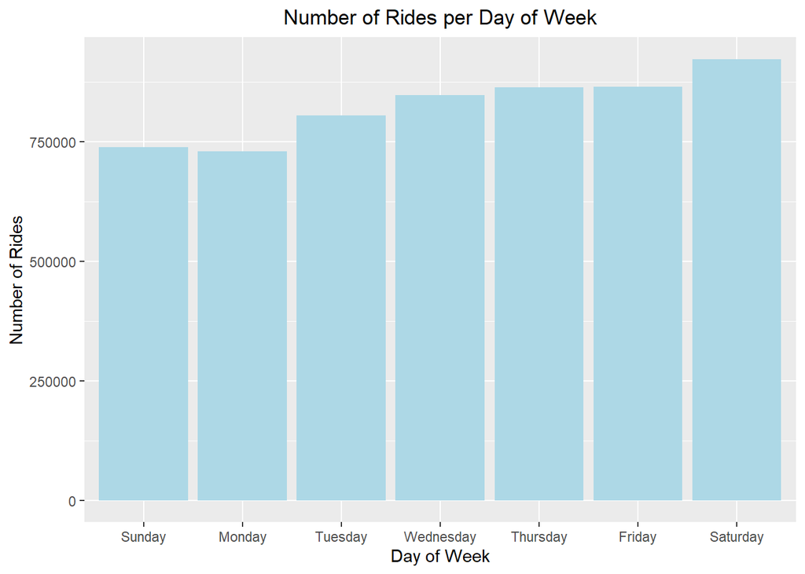

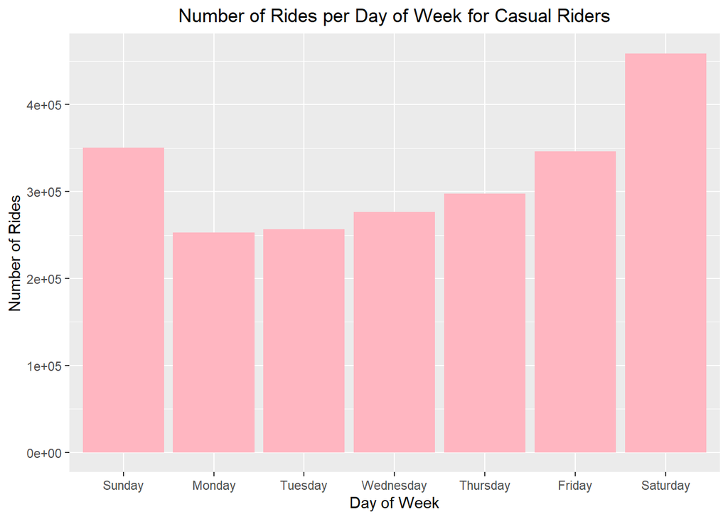

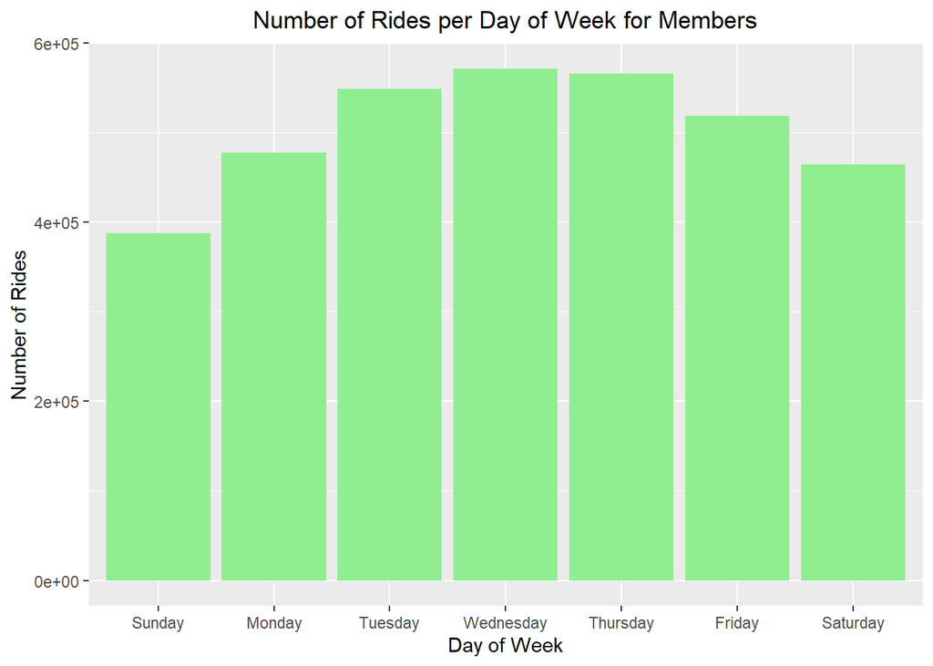

*Do casual riders and members differ on which days of the week they are most likely to use Cylcistic?*

When rides per day are split between casual riders and members, an inverse pattern occurs; casual users ride most on weekends while members ride most on weekdays. There was less variation for overall riders compared to data split between casual riders and members. **This pattern is likely due to members commuting to work while casual users ride for pleasure.**

### Figure 4. Rides per Day of Week by Month

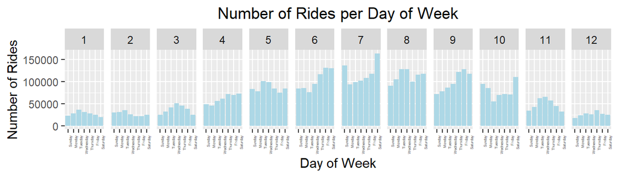

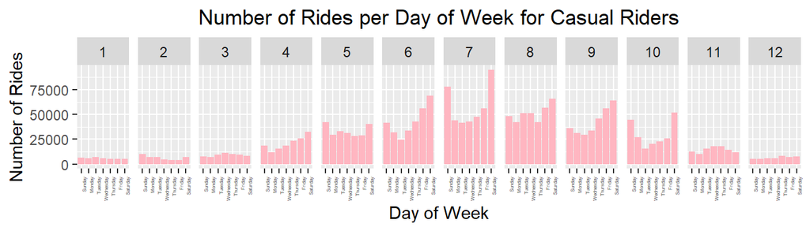

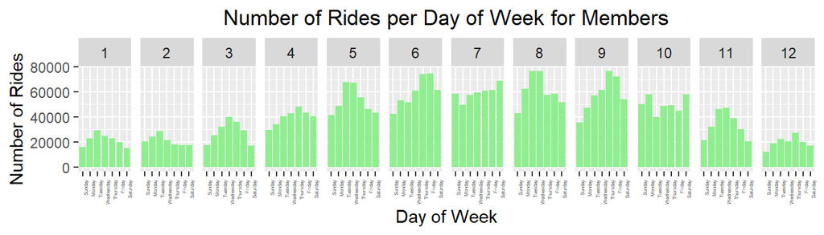

*Do patterns of daily popularity change month-to-month for casual users or members?*

Member preference for weekday trips does not hold in July or October and weekend trips instead become more popular. Casual rider preference for weekend trips also fails to hold in winter months and weekday trips become more popular. **This is likely because in colder months trips are much more likely to be for business (commutes) and in warmer months they’re much more likely to be for pleasure (taken on weekends).**

In August casual riders rode on weekdays almost as much as weekends. **This might have been caused by a large number of tourists vacationing during the weekdays as well, or more casual riders might have been using bikes to commute.**

Calculate most popular start station for casual riders and members

```r
find_mode(subset(cyclist_compiled_final, member_casual == "casual" & start_station_name != "NA")$start_station_name)
```

```
## [1] "Streeter Dr & Grand Ave"
```

```r
find_mode(subset(cyclist_compiled_final, member_casual == "member" & start_station_name != "NA")$start_station_name)
```

```
## [1] "Kingsbury St & Kinzie St"
```

### Figure 5. Most Popular Start Stations

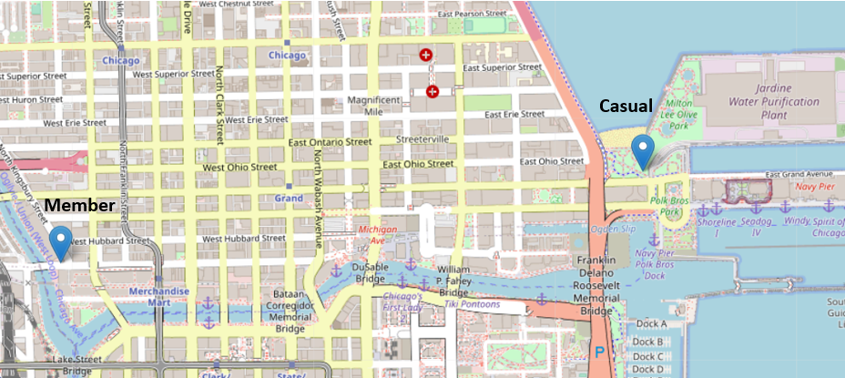

*Are casual riders and members most likely to begin a trip from different places?*

Casual riders were most likely to begin their trip from Streeter Drive and Grand Avenue, which is the Navy Pier station. Members were most likely to begin their trip closer to downtown from the station at Kingsbury Street and Kinzie Street. **This suggests casual riders are likely to be tourists as Navy Pier is a popular Chicago tourist destination.**

### Figure 6. Bike Type Popularity and Ride Lenght by Bike Type

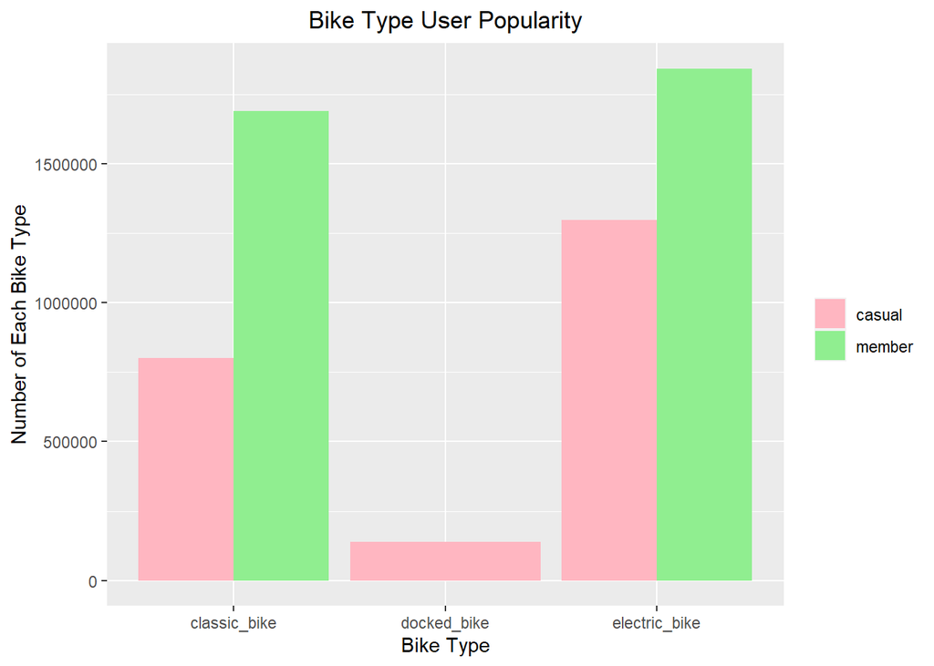

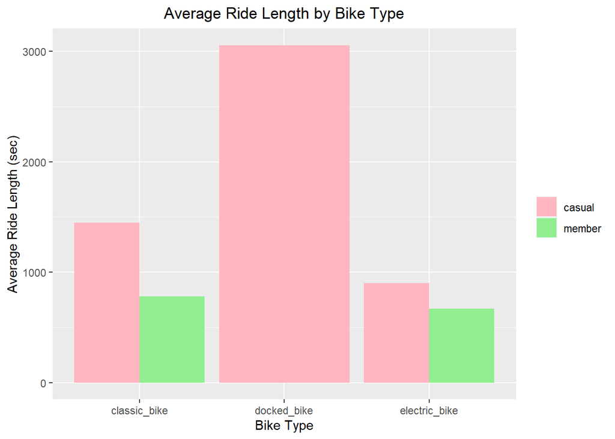

*Do casual riders and members prefer different bike types?*

Both casual riders and members prefer electric bikes to classic bikes, though the preference is stronger for casual riders. Docked bikes are only used by casual riders. Docked bikes had by far the longest rides. Casual users were more likely to use classic bikes for longer, perhaps for pleasure or exercise rather than commutes. There was no data provided about accessibility bikes.

## Recomendations:

Casual riders and members use Cyclistic for different purposes. Members take shorter rides on weekdays while casual users take longer rides on weekends. This pattern suggests that members are usually riding to commute while casual users mostly ride for pleasure. Month-to-month data supports the business vs. pleasure theory as members take more long weekend rides in the warmer weather and far more weekday rides in the winter. Starting station data provides further insight into causal riders as the most popular starting station was at Navy Pier, while the most popular starting station for members was downtown, suggesting casual riders are often tourists.

Given these findings, further analysis may benefit from breaking casual riders into groups of likely, possible, and unlikely to be converted when researching what might turn a casual user into a member. The popularity of the Navy Pier starting station suggests that a sizeable number of casual riders are tourists and would be very unlikely to convert. Oppositely, casual riders most likely to become members might be found by filtering for member-like behavior, such as short weekday rides most of the year, as they may benefit most from membership. Inversely, members could be filtered for casual-rider behavior (mostly weekend use) and interviewed about why membership is worthwhile for non-commuters. The prevalence of commuting in membership also suggests that convincing casual riders to bike to work may cause conversion and is a potential avenue for the team researching social media influence on the Cyclistic community.

One further suggestion is to incorporate information on accessibility bikes if available might provide further insight and suggestions as they make up 8% of ridership but were not included in the dataset.